# So sánh **BiLSTM** và **Transformer** cho phát hiện ngôn từ thù ghét tiếng Việt (ViHSD)

> Đồ án môn *Toán cho AI* — xây dựng, huấn luyện và **so sánh** hai kiến trúc học sâu trên cùng một bộ dữ liệu, đồng thời phân tích **các phương pháp xử lý dữ liệu / huấn luyện** bằng thí nghiệm cắt bỏ (*ablation*) và biểu đồ minh hoạ.

**Bài toán.** Phân loại 3 lớp một bình luận mạng xã hội: `0 = CLEAN` (bình thường), `1 = OFFENSIVE` (công kích), `2 = HATE` (thù ghét).

**Notebook này làm gì?** Nạp lại toàn bộ kết quả đã huấn luyện (trong `results/metrics/`) và **vẽ lại tại chỗ** các biểu đồ giám sát & so sánh. Toàn bộ mã huấn luyện nằm trong gói `src/` và `run_all.py`. Đặt `RUN_TRAINING=True` ở cell dưới để huấn luyện lại từ đầu trên GPU.

Mục lục:

1. Cấu hình & nạp dữ liệu kết quả
2. Khám phá dữ liệu (EDA) — vì sao mất cân bằng & nhiễu là vấn đề
3. Tiền xử lý tiếng Việt (demo trực tiếp) + lý thuyết
4. Hai kiến trúc & nền tảng toán học (LSTM, Self-Attention, Positional Encoding)
5. Phương pháp huấn luyện (loss có trọng số/focal, warmup, gradient clipping, early stopping)
6. Giám sát huấn luyện (loss/acc/F1, gradient-norm, learning-rate)
7. Đánh giá trên test (confusion, F1 theo lớp, ROC/PR) + bản đồ attention
8. **Ablation** — có/không dùng từng phương pháp thì sao?
9. Kết luận

## 1. Cấu hình & nạp kết quả

```python
import os, sys, json, warnings
warnings.filterwarnings("ignore")
sys.path.insert(0, os.path.abspath("."))          # để import gói src
import numpy as np, pandas as pd
from pathlib import Path
from IPython.display import Image, display, Markdown
from src import plots
from src.config import FIG_DIR, MET_DIR, LABEL_NAMES

RUN_TRAINING = False   # True -> chạy lại run_all.py (cần GPU, ~25-30 phút)
if RUN_TRAINING:
    import subprocess; subprocess.run([sys.executable, "run_all.py"], check=True)

def load(name): return json.load(open(MET_DIR / name, encoding="utf-8"))
def show(path): display(Image(filename=str(path)))

eda      = load("eda.json")
meta     = load("data_meta.json")
logs     = load("training_logs.json")
results  = load("test_results.json")
cost     = load("cost.json")
abl      = load("ablations.json")
attn_ex  = load("attention_example.json")
arrays   = np.load(MET_DIR / "test_arrays.npz")
# gắn lại mảng xác suất vào results để vẽ ROC/PR (json đã lược bỏ mảng lớn)
for m in ("lstm", "transformer"):
    results[m]["y_true"] = arrays[f"{m}_y_true"]
    results[m]["y_pred"] = arrays[f"{m}_y_pred"]
    results[m]["prob"]   = arrays[f"{m}_prob"]
print("Đã nạp kết quả cho:", list(results.keys()))
print("Kích thước từ điển:", meta["vocab_size"], "| trọng số lớp:",
      [round(w,3) for w in meta["class_weights"]])
```

```
Đã nạp kết quả cho: ['lstm', 'transformer']
Kích thước từ điển: 5737 | trọng số lớp: [0.403, 4.991, 3.136]
```

## 2. Khám phá dữ liệu (EDA)

Ba tập `train / dev / test` với cột `free_text` (bình luận) và `label_id` (nhãn 0/1/2). Hai đặc điểm chi phối mọi quyết định thiết kế:

### 2.1 Mất cân bằng lớp nghiêm trọng

Lớp `CLEAN` chiếm ~83%, hai lớp cần phát hiện (`OFFENSIVE`, `HATE`) chỉ ~7% và ~11%.

> **Hệ quả toán học.** Một bộ phân loại "luôn đoán CLEAN" đạt **accuracy ≈ 83%** nhưng **vô dụng** (không bắt được câu thù ghét nào). Vì vậy ta KHÔNG dùng accuracy làm thước đo chính, mà dùng **macro-F1** — trung bình **không trọng số** của F1 ba lớp, nên lớp thiểu số có tiếng nói ngang lớp đa số: $$\text{macro-F1}=\frac{1}{K}\sum_{c=1}^{K} F1_c,\qquad F1_c=\frac{2\,P_c R_c}{P_c+R_c},\quad P_c=\frac{TP_c}{TP_c+FP_c},\ R_c=\frac{TP_c}{TP_c+FN_c}.$$

```
Số mẫu mỗi lớp:
            train   dev  test
CLEAN      19886  2190  5548
OFFENSIVE   1606   212   444
HATE        2556   270   688

Tỉ lệ % mỗi lớp:
            train    dev   test
CLEAN      82.69  81.96  83.05
OFFENSIVE   6.68   7.93   6.65
HATE       10.63  10.10  10.30
```

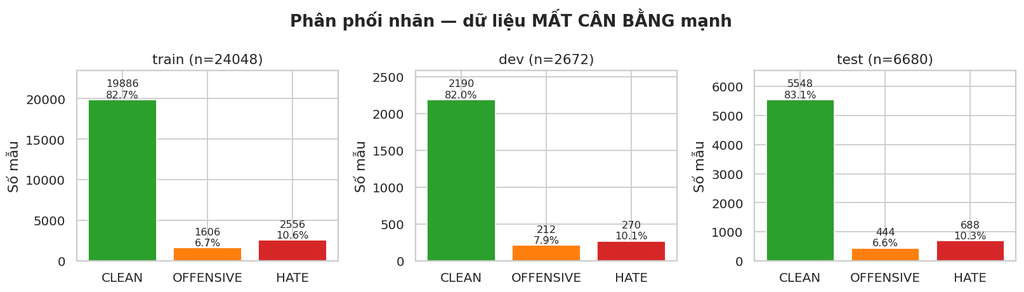

```python
df_dist = pd.DataFrame(eda["label_counts"], index=LABEL_NAMES)
df_pct  = pd.DataFrame(eda["label_pct"],   index=LABEL_NAMES).round(2)
print("Số mẫu mỗi lớp:\n", df_dist, "\n\nTỉ lệ % mỗi lớp:\n", df_pct)
show(FIG_DIR / "01_label_distribution.png")
```

### 2.2 Độ dài câu — chọn `max_len`

Phần lớn câu rất ngắn (trung vị ~8 token) nhưng đuôi phải dài. Ta cắt/đệm về `max_len = 64` (~phân vị 99) để cân bằng giữa **giữ thông tin** và **chi phí tính toán** (self-attention tốn $O(L^2)$ theo độ dài $L$).

```
            mean  median   p90    p99     max
train  12.208500     8.0  24.0  64.53  1754.0
dev    12.191617     9.0  25.0  65.00   138.0
test   12.234731     8.0  25.0  65.00   434.0
```

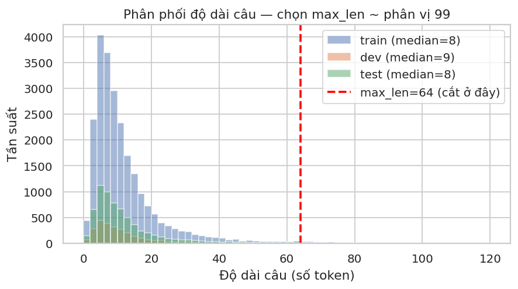

```python
print(pd.DataFrame(eda["length"]).T)
show(FIG_DIR / "02_length_hist.png")
```

### 2.3 Nhiễu đặc thù tiếng Việt → động lực cho tiền xử lý

Dữ liệu là bình luận thật: teencode (`ko`→`không`), emoji/emoticon (`:))`, `❤️`), kéo dài ký tự (`quááá`). Token `:))` và `ko` nằm trong nhóm xuất hiện nhiều nhất. Biểu đồ dưới so sánh **tỉ lệ OOV** (token rơi vào `<unk>`) khi **có** và **không** tiền xử lý — tiền xử lý kéo OOV giảm rõ rệt (xem mục 3 & 8).

```
OOV (có làm sạch): {'train': 0.0127, 'dev': 0.0206, 'test': 0.0218}
OOV (không làm sạch): {'train': 0.0389, 'dev': 0.0516, 'test': 0.0544}
Vocab: clean = 5737 | raw = 7598
```

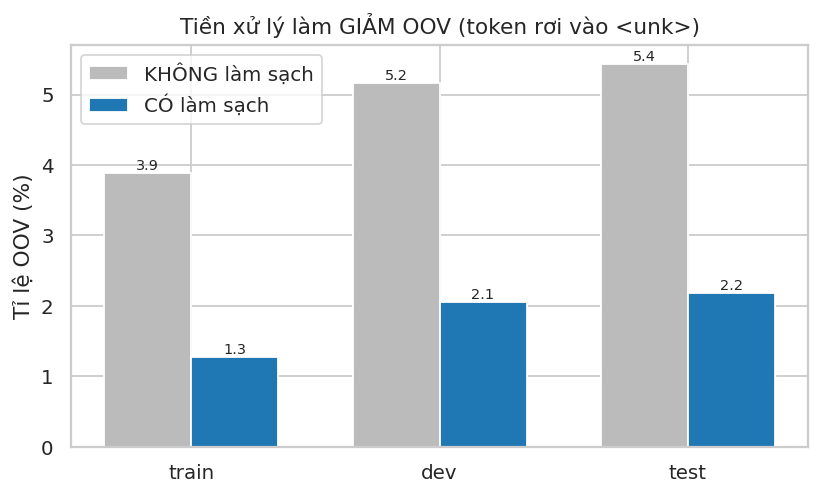

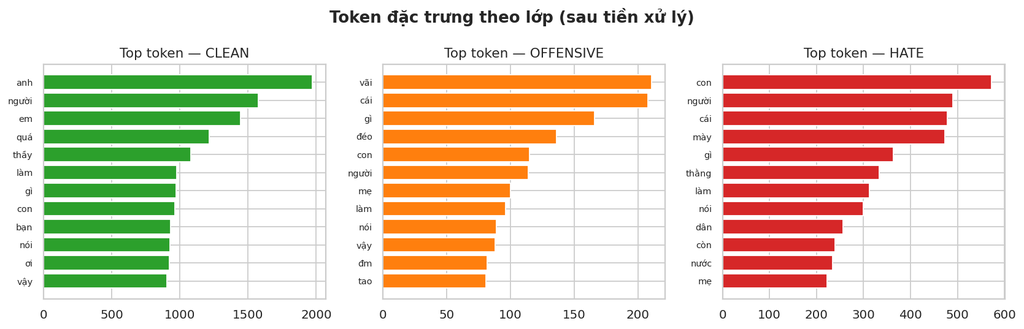

```python
print("OOV (có làm sạch):", eda["oov_clean"])
print("OOV (không làm sạch):", eda["oov_raw"])
print("Vocab: clean =", eda["vocab_clean"], "| raw =", eda["vocab_raw"])
show(FIG_DIR / "03_oov_clean_vs_raw.png")
show(FIG_DIR / "04_top_tokens.png")
```

## 3. Tiền xử lý văn bản tiếng Việt — lý thuyết & demo

Pipeline (`src/preprocessing.py`) gồm các bước, mỗi bước có **lý do** và **rủi ro nếu bỏ**:

[output not shown]

> **Vì sao OOV quan trọng (toán học).** Mỗi token tra một vector nhúng $E_i\in\mathbb R^d$. Token ngoài từ điển bị thay bằng **một** vector `<unk>` dùng chung → mất khả năng phân biệt. OOV cao ⇒ nhiều câu bị "xoá nhoà" thành chuỗi `<unk>` ⇒ mô hình mất thông tin đầu vào.

```python
from src.preprocessing import clean_text, simple_tokenize
demo = [
 "Em được làm fan cứng luôn rồi nè ❤️ reaction quá hay quá cute coi mấy giờ này =]]]",
 "ko hiểu sao bọn nó cứ chửi nhau =))))) vcl thật sự",
 "Đm thằng này ngu vl :)) đọc link https://abc.xyz đi @user gọi 0901234567",
]
for s in demo:
    print("RAW  :", s)
    print("RAW-tok (no-clean):", simple_tokenize(s))
    print("CLEAN:", clean_text(s)); print("-"*100)
```

```
RAW  : Em được làm fan cứng luôn rồi nè ❤️ reaction quá hay quá cute coi mấy giờ này =]]]
RAW-tok (no-clean): em được làm fan cứng luôn rồi nè ❤️ reaction quá hay quá cute coi mấy giờ này =]]]
CLEAN: em được làm fan cứng luôn rồi nè <heart_emo> reaction quá hay quá cute coi mấy giờ này <troll_emo>
----------------------------------------------------------------------------------------------------
RAW  : ko hiểu sao bọn nó cứ chửi nhau =))))) vcl thật sự
RAW-tok (no-clean): ko hiểu sao bọn nó cứ chửi nhau =))))) vcl thật sự
CLEAN: không hiểu sao bọn nó cứ chửi nhau <pos_emo> vãi thật sự
----------------------------------------------------------------------------------------------------
RAW  : Đm thằng này ngu vl :)) đọc link https://abc.xyz đi @user gọi 0901234567
RAW-tok (no-clean): đm thằng này ngu vl :)) đọc link https://abc.xyz đi @user gọi 0901234567
CLEAN: đm thằng này ngu vãi <pos_emo> đọc link <url> đi <user> gọi <phone>
----------------------------------------------------------------------------------------------------
```

## 4. Hai kiến trúc & nền tảng toán học

### 4.1 BiLSTM (hồi quy)

LSTM xử lý **tuần tự**, tại mỗi bước $t$ cập nhật trạng thái nhớ $c_t$ và ẩn $h_t$ qua các *cổng*: $$ \begin{aligned} f_t&=\sigma(W_f[h_{t-1},x_t]+b_f) &\text{(quên)}\\ i_t&=\sigma(W_i[h_{t-1},x_t]+b_i) &\text{(nạp)}\\ \tilde c_t&=\tanh(W_c[h_{t-1},x_t]+b_c)\\ c_t&=f_t\odot c_{t-1}+i_t\odot \tilde c_t &\text{(ô nhớ)}\\ o_t&=\sigma(W_o[h_{t-1},x_t]+b_o),\quad h_t=o_t\odot\tanh(c_t) \end{aligned} $$ Cổng quên $f_t$ tạo "đường cao tốc" cho gradient ($\partial c_t/\partial c_{t-1}=f_t$) ⇒ giảm **triệt tiêu gradient** so với RNN thường. **Bi**directional: chạy 2 chiều rồi nối $h_t=[\overrightarrow{h_t};\overleftarrow{h_t}]$ để mỗi vị trí thấy cả ngữ cảnh trái–phải. Độ phức tạp $O(L)$ nhưng **tuần tự** (khó song song theo thời gian).

### 4.2 Transformer Encoder (self-attention)

Mọi token "nhìn" mọi token **song song**. Lõi là *Scaled Dot-Product Attention*: $$\text{Attention}(Q,K,V)=\operatorname{softmax}\!\Big(\frac{QK^\top}{\sqrt{d_k}}\Big)V,$$ với $Q=XW_Q,\,K=XW_K,\,V=XW_V$. Tích $QK^\top$ đo độ tương hợp mọi cặp token; chia $\sqrt{d_k}$ giữ phương sai ổn định để softmax không bão hoà. **Multi-head**: chạy $h$ "đầu" song song trên các không gian con $d_k=d/h$ rồi nối lại — học nhiều kiểu quan hệ. Mỗi lớp encoder (Pre-LN): $$x\leftarrow x+\text{MHA}(\text{LN}(x)),\qquad x\leftarrow x+\text{FFN}(\text{LN}(x)).$$ Độ phức tạp $O(L^2 d)$ (đắt hơn theo độ dài) nhưng **song song hoàn toàn** và đường đi thông tin giữa 2 token bất kỳ chỉ dài $O(1)$ (LSTM là $O(L)$) ⇒ bắt phụ thuộc xa tốt hơn về lý thuyết.

### 4.3 Positional Encoding — vì sao **bắt buộc** với Transformer

Self-attention **bất biến hoán vị**: đổi thứ tự token, tập đầu ra chỉ bị hoán vị tương ứng ⇒ *"tôi ghét bạn"* và *"bạn ghét tôi"* có cùng biểu diễn nếu không thêm vị trí. Ta cộng mã vị trí sin/cos: $$PE_{(pos,2i)}=\sin\!\big(pos/10000^{2i/d}\big),\quad PE_{(pos,2i+1)}=\cos\!\big(pos/10000^{2i/d}\big).$$ (LSTM **không cần** vì thứ tự đã ngầm trong tính tuần tự.) Ablation ở mục 8 đo tác động thực tế.

```python
# Dựng mô hình (không huấn luyện) để in kiến trúc & đếm tham số
import torch
from src.config import Config
from src.models import build_model, count_params
cfg = Config()
for name in ("lstm", "transformer"):
    m = build_model(name, meta["vocab_size"], cfg)
    print(f"\n===== {name.upper()} =====  tham số: {count_params(m)/1e6:.2f}M")
    print(m)
```

```
===== LSTM =====  tham số: 2.01M
BiLSTMClassifier(
  (embed): Embedding(5737, 200, padding_idx=0)
  (emb_drop): Dropout(p=0.3, inplace=False)
  (lstm): LSTM(200, 128, num_layers=2, batch_first=True, dropout=0.3, bidirectional=True)
  (head): Sequential(
    (0): Linear(in_features=512, out_features=256, bias=True)
    (1): ReLU()
    (2): Dropout(p=0.3, inplace=False)
    (3): Linear(in_features=256, out_features=3, bias=True)
  )
)

===== TRANSFORMER =====  tham số: 1.96M
TransformerClassifier(
  (embed): Embedding(5737, 200, padding_idx=0)
  (pos): PositionalEncoding()
  (emb_drop): Dropout(p=0.3, inplace=False)
  (layers): ModuleList(
    (0-1): 2 x EncoderLayer(
      (ln1): LayerNorm((200,), eps=1e-05, elementwise_affine=True)
      (attn): MultiHeadSelfAttention(
        (qkv): Linear(in_features=200, out_features=600, bias=True)
        (proj): Linear(in_features=200, out_features=200, bias=True)
        (drop): Dropout(p=0.3, inplace=False)
      )
      (ln2): LayerNorm((200,), eps=1e-05, elementwise_affine=True)
      (ff): Sequential(
        (0): Linear(in_features=200, out_features=512, bias=True)
        (1): GELU(approximate='none')
        (2): Dropout(p=0.3, inplace=False)
        (3): Linear(in_features=512, out_features=200, bias=True)
      )
      (drop): Dropout(p=0.3, inplace=False)
    )
  )
  (norm): LayerNorm((200,), eps=1e-05, elementwise_affine=True)
  (head): Sequential(
    (0): Linear(in_features=400, out_features=200, bias=True)
    (1): ReLU()
    (2): Dropout(p=0.3, inplace=False)
    (3): Linear(in_features=200, out_features=3, bias=True)
  )
)
```

## 5. Phương pháp huấn luyện

### 5.3 **Gradient clipping**

Chặn chuẩn gradient: nếu $\lVert g\rVert_2>\tau$ thì $g\leftarrow \tau\,g/\lVert g\rVert_2$. Ngăn "vách gradient" gây bước nhảy huỷ hoại (bùng nổ gradient). Mục 6/8 vẽ chuẩn gradient để thấy.

### 5.4 **Early stopping** theo dev macro-F1

Dừng khi macro-F1 trên `dev` không cải thiện sau `patience` epoch, giữ lại checkpoint tốt nhất ⇒ chống overfit, tiết kiệm tính toán. Ta theo dõi macro-F1 (không phải loss) vì đó là mục tiêu thật.

## 6. Giám sát quá trình huấn luyện

Bốn bảng theo dõi mỗi epoch: **loss** (train liền nét, dev nét đứt — chênh lệch lớn = overfit), **accuracy**, **dev macro-F1** (chỉ số chọn mô hình), và **learning-rate** (thấy rõ warmup+decay).

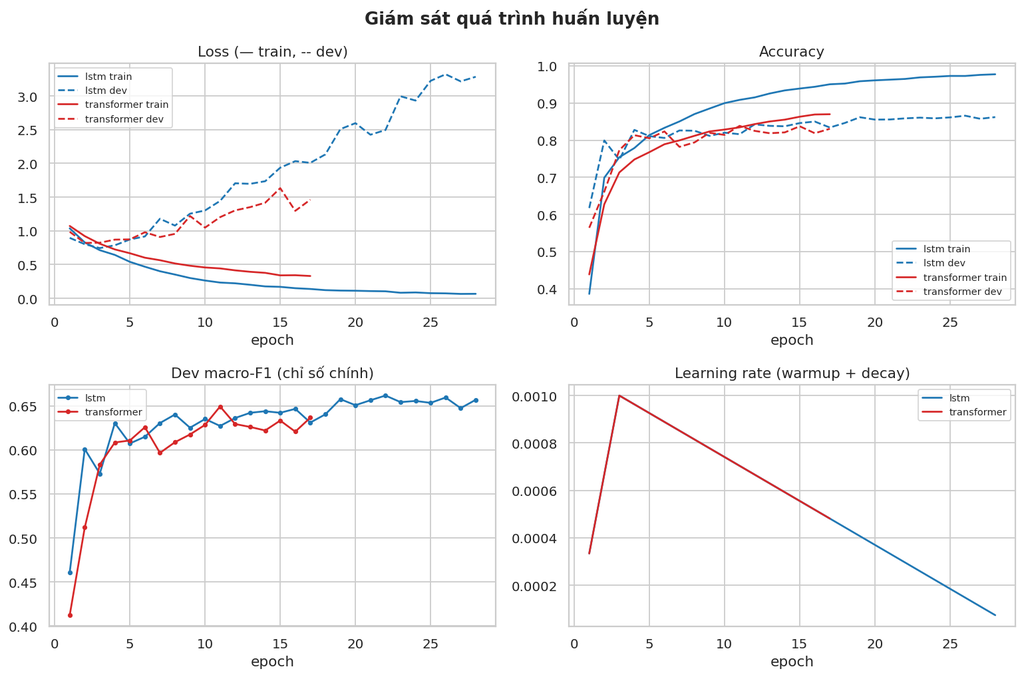

```python
hist = logs["histories"]; steps = logs["step_logs"]
show(plots.plot_training_curves(hist, FIG_DIR / "05_training_curves.png"))
```

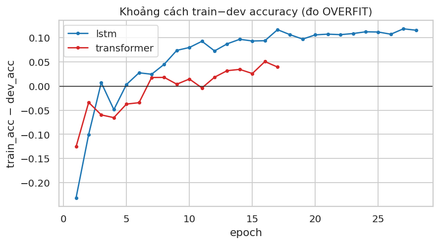

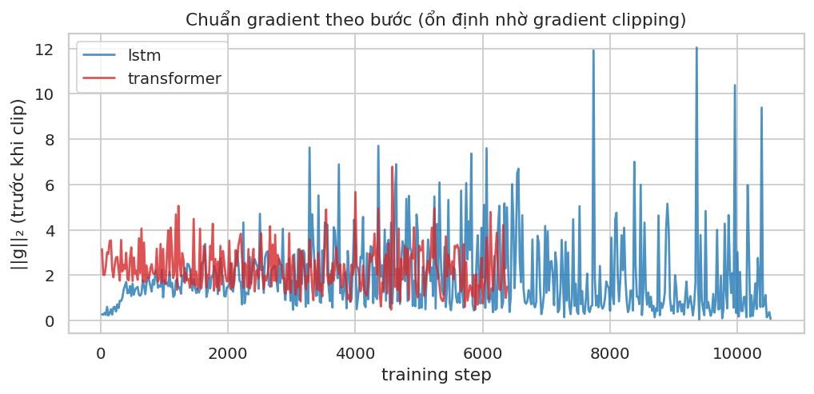

```
             epoch tốt nhất  dev macroF1 (best)  thời gian/epoch (s)  \
lstm                   22.0              0.6618                 12.6
transformer            11.0              0.6493                  5.0

             tham số (M)
lstm                2.01
transformer         1.96
```

```python
show(plots.plot_overfit_gap(hist, FIG_DIR / "06_overfit_gap.png"))
show(plots.plot_grad_norm(steps, FIG_DIR / "07_grad_norm.png"))
# bảng tóm tắt hội tụ
summ = pd.DataFrame({m: {
    "epoch tốt nhất": cost[m]["best_epoch"],
    "dev macroF1 (best)": round(cost[m]["best_dev_macro_f1"],4),
    "thời gian/epoch (s)": round(cost[m]["time_per_epoch"],1),
    "tham số (M)": round(cost[m]["params"]/1e6,2),
} for m in ("lstm","transformer")}).T
print(summ)
```

## 7. Đánh giá trên tập test

### 7.1 Ma trận nhầm lẫn (chuẩn hoá theo hàng = **recall** mỗi lớp)

Đường chéo càng đậm càng tốt. Chú ý lớp `OFFENSIVE`/`HATE` — nơi khó nhất.

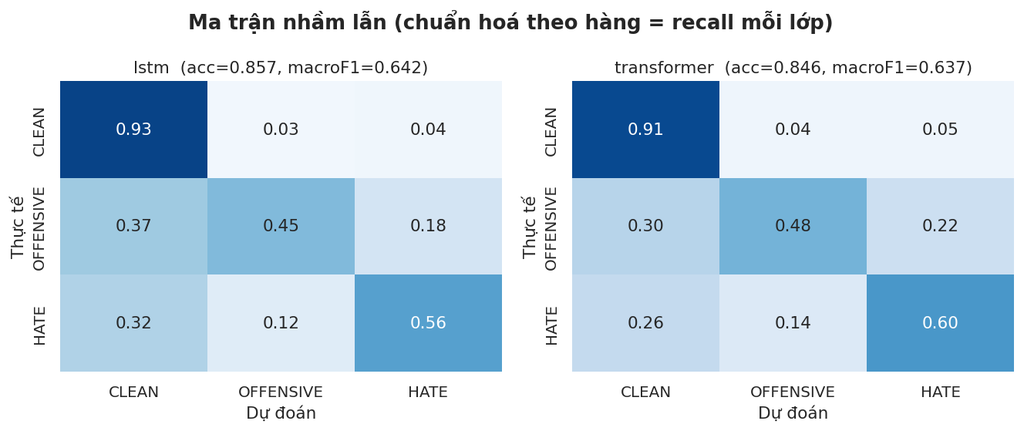

| model | accuracy | macro-F1 | weighted-F1 | F1_CLEAN | F1_OFFENSIVE | F1_HATE |
| --- | --- | --- | --- | --- | --- | --- |
| lstm | 0.8572 | 0.6419 | 0.8581 | 0.929 | 0.433 | 0.564 |
| transformer | 0.8463 | 0.6372 | 0.8531 | 0.923 | 0.428 | 0.560 |

```python
show(plots.plot_confusion(results, FIG_DIR / "08_confusion.png", normalize=True))
# báo cáo chi tiết
rows = []
for m in ("lstm","transformer"):
    r = results[m]
    rows.append({"model": m, "accuracy": round(r["acc"],4),
                 "macro-F1": round(r["macro_f1"],4), "weighted-F1": round(r["weighted_f1"],4),
                 **{f"F1_{LABEL_NAMES[i]}": round(r["per_class_f1"][i],3) for i in range(3)}})
display(pd.DataFrame(rows).set_index("model"))
```

### 7.2 F1 theo từng lớp & đường cong ROC / Precision–Recall (one-vs-rest)

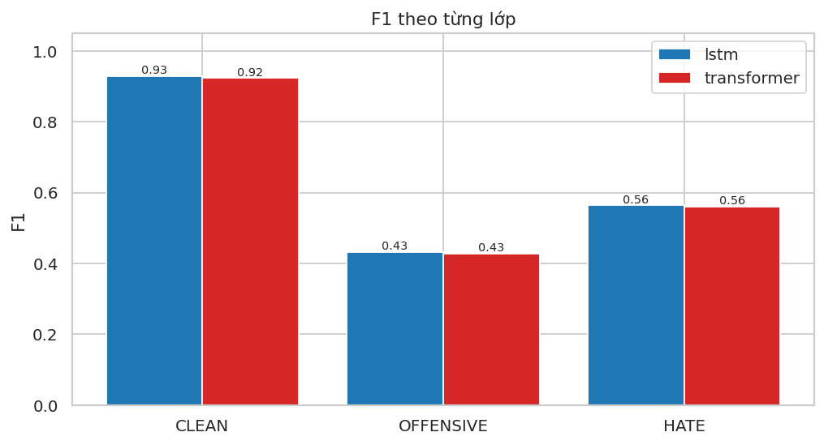

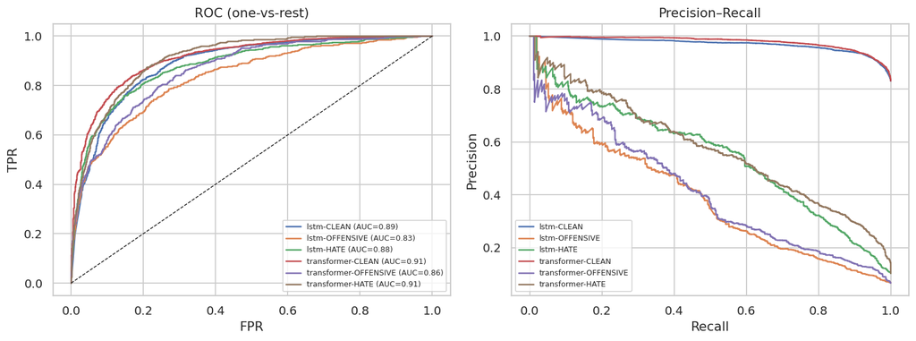

```python
show(plots.plot_per_class_f1(results, FIG_DIR / "09_per_class_f1.png"))
show(plots.plot_roc_pr(results, FIG_DIR / "10_roc_pr.png"))
```

### 7.3 Bản đồ Self-Attention (khả diễn giải của Transformer)

Lấy một câu `HATE` thật, vẽ ma trận attention lớp cuối (trung bình các đầu). Hàng = token *truy vấn*, cột = token được *chú ý*. Đây là điều LSTM **không** cung cấp trực tiếp.

```
Câu (token): ôi bố cái lũ thanh niên hãm lol . đẹp mặt quá <emoji> <emoji> | dự đoán: OFFENSIVE
```

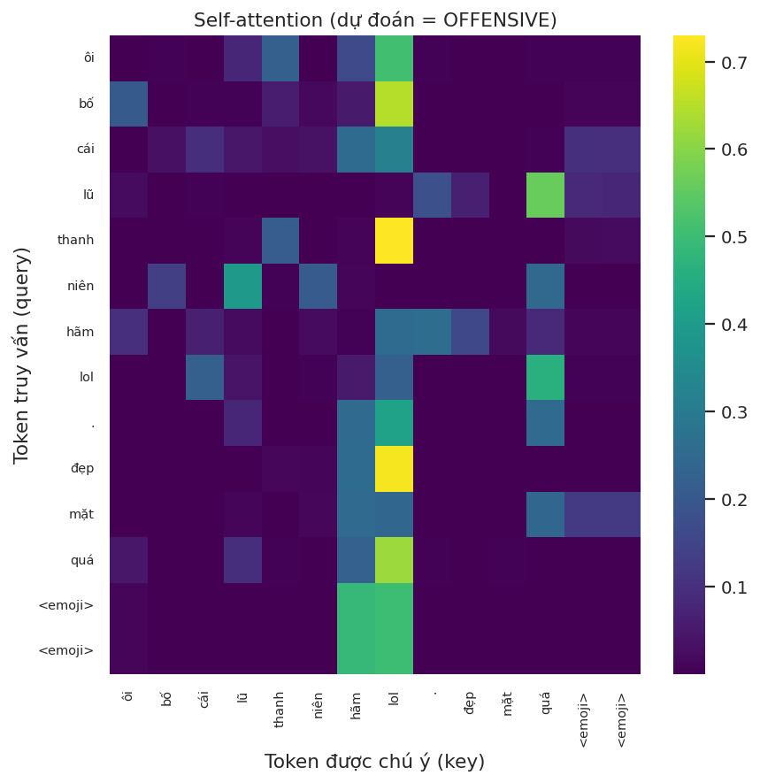

```python
toks = attn_ex["tokens"]; A = np.array(attn_ex["attn"])
print("Câu (token):", " ".join(toks), "| dự đoán:", LABEL_NAMES[attn_ex["pred"]])
show(plots.plot_attention(toks, A, FIG_DIR / "13_attention.png",
     title=f"Self-attention (dự đoán = {LABEL_NAMES[attn_ex['pred']]})"))
```

## 8. Ablation — "có" vs "không" dùng từng phương pháp

Mỗi thí nghiệm **chỉ đổi một yếu tố**, huấn luyện lại và đo trên test. Cột **đỏ** = bỏ phương pháp.

|  | cấu hình | macro-F1 | recall CLEAN | recall OFFENSIVE | recall HATE |
| --- | --- | --- | --- | --- | --- |
| 0 | LSTM +CW | 0.6442 | 0.924 | 0.480 | 0.552 |
| 1 | LSTM −CW | 0.6440 | 0.948 | 0.394 | 0.541 |
| 2 | TF +CW | 0.6239 | 0.891 | 0.561 | 0.529 |
| 3 | TF −CW | 0.6254 | 0.955 | 0.437 | 0.414 |

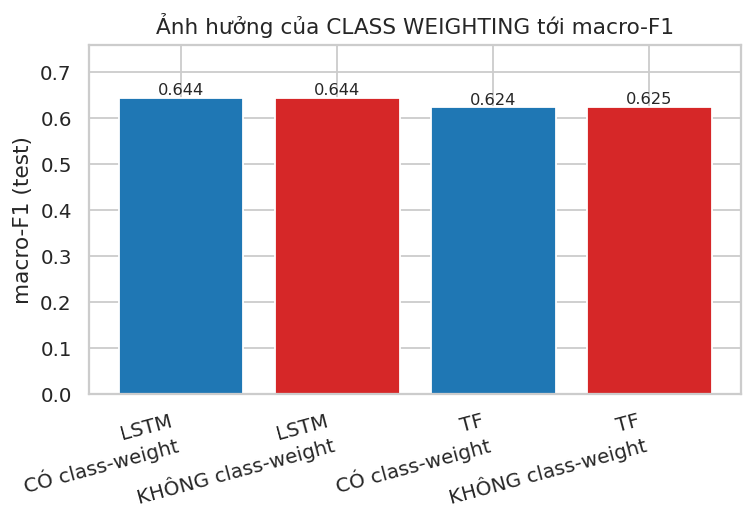

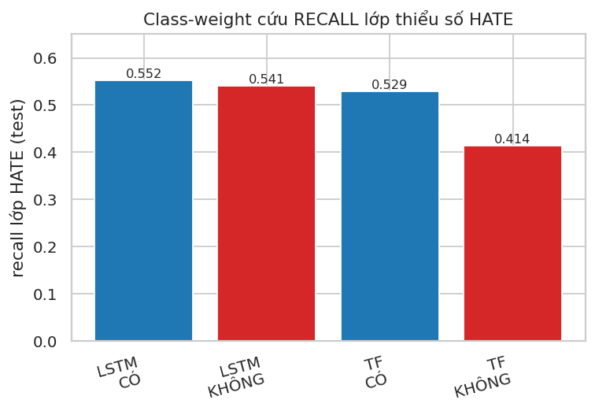

```python
def g(k, field):
    v = abl[k]; return v[field] if not isinstance(v.get(field), list) else v[field]
tab = []
for k,lab in [("lstm_with_cw","LSTM +CW"),("lstm_no_cw","LSTM −CW"),
              ("tf_with_cw","TF +CW"),("tf_no_cw","TF −CW")]:
    tab.append({"cấu hình":lab,"macro-F1":round(abl[k]["macro_f1"],4),
                "recall CLEAN":round(abl[k]["per_class_recall"][0],3),
                "recall OFFENSIVE":round(abl[k]["per_class_recall"][1],3),
                "recall HATE":round(abl[k]["per_class_recall"][2],3)})
display(pd.DataFrame(tab))
show(FIG_DIR / "14_ablation_classweight_f1.png")
show(FIG_DIR / "15_ablation_classweight_recall.png")
```

### 8.2 Positional Encoding (Transformer)

Bỏ mã vị trí: self-attention trở nên **bất biến thứ tự** ⇒ mất thông tin trật tự từ.

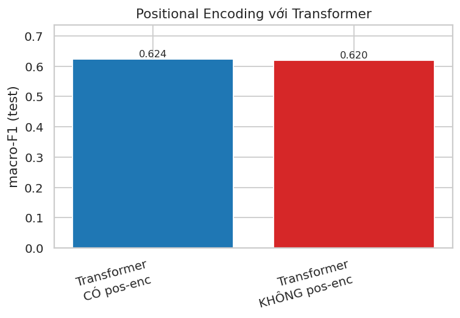

```python
show(FIG_DIR / "16_ablation_posenc.png")
```

### 8.3 Tiền xử lý tiếng Việt (làm sạch)

```
OOV & vocab: {'oov_clean': {'train': 0.012735447392622364, 'dev': 0.020567288801571708, 'test': 0.021816268598277212}, 'oov_raw': {'train': 0.03892922058446228, 'dev': 0.05163723864338438, 'test': 0.054368653623056165}, 'vocab_clean': 5737, 'vocab_raw': 7598}
```

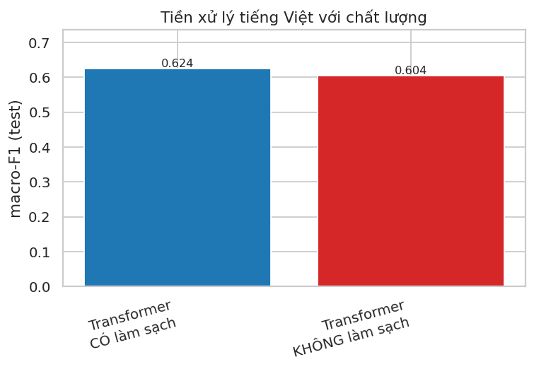

```python
print("OOV & vocab:", {k:abl["_meta"][k] for k in abl["_meta"]})
show(FIG_DIR / "17_ablation_clean.png")
```

### 8.4 LR Warmup & Gradient Clipping (ổn định huấn luyện)

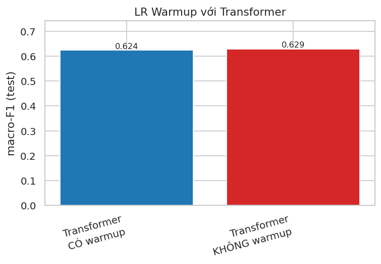

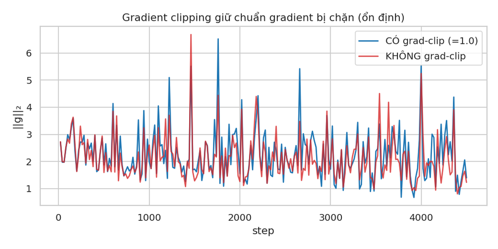

```python
show(FIG_DIR / "18_ablation_warmup.png")
show(FIG_DIR / "19_ablation_gradclip.png")
```

## 9. So sánh tổng thể & kết luận

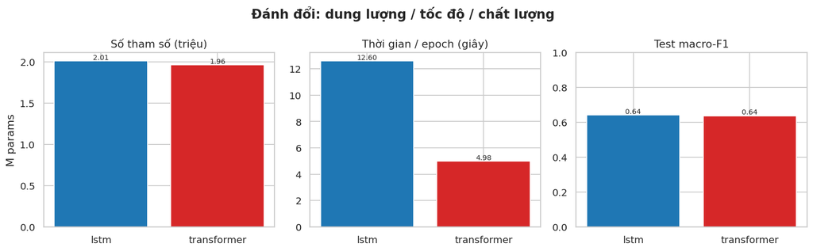

|  | test accuracy | test macro-F1 | tham số (M) | thời gian/epoch (s) |
| --- | --- | --- | --- | --- |
| lstm | 0.8572 | 0.6419 | 2.01 | 12.6 |
| transformer | 0.8463 | 0.6372 | 1.96 | 5.0 |

```python
show(plots.plot_model_cost(cost, FIG_DIR / "12_model_cost.png"))
final = pd.DataFrame({m:{"test accuracy":round(results[m]["acc"],4),
                         "test macro-F1":round(results[m]["macro_f1"],4),
                         "tham số (M)":round(cost[m]["params"]/1e6,2),
                         "thời gian/epoch (s)":round(cost[m]["time_per_epoch"],1)}
                      for m in ("lstm","transformer")}).T
display(final)
```

> Toàn bộ phương pháp, lý thuyết toán học và phân tích chi tiết xem trong `README.md`.